# F1 Safety Analysis

2024-12-30

# F1 Safety

Often called the pinnacle of Motorsport, formula 1 racing is watched by millions of fans every year. Because there is so much speed involved, it can be a very dangerous endeavor. In the past, mistakes in the sport could be deadly. Nevertheless, the sport endured. There have been many attempts to make the sport more safe. In this analysis we look to see if those steps have been successful.

## Question

How have the safety measures put into place in formula one impacted the safety of the sport?

## Data

All data comes from [this](https://www.kaggle.com/datasets/jtrotman/formula-1-race-events?resource=download&select=fatal_accidents_drivers.csv) Kaggle data set. This includes fatal accidents for both drivers and marshals, red flags, and safety cars.

## Data Cleaning

### Packages

These are the packages we will need to do our data cleaning and analysis.

```r
library(magrittr)
library(tidyverse)
library(reshape)
```

### Importing Datasets

We will load the data sets we need here.

### Formatting

This will allow us to reformat the data frames in ways that will be useful to our analysis. Mainly we are separating the year and name of each event into separate entries in each row.

```r
safetyCarData <- safety_cars %>%
  mutate(Year = substring(Race, 1, 4)) %>%
  mutate(Track = substring(Race, 6)) %>%
  mutate(Year = as.numeric(Year))

DriverDeaths <- fatal_accidents_drivers %>%
  mutate(Year = substring(Event, 1, 4)) %>%
  mutate(Track = substring(Event, 6)) %>%
  mutate(Year = as.numeric(Year))
```

### Plots

#### Safety Cars Against Driver Deaths

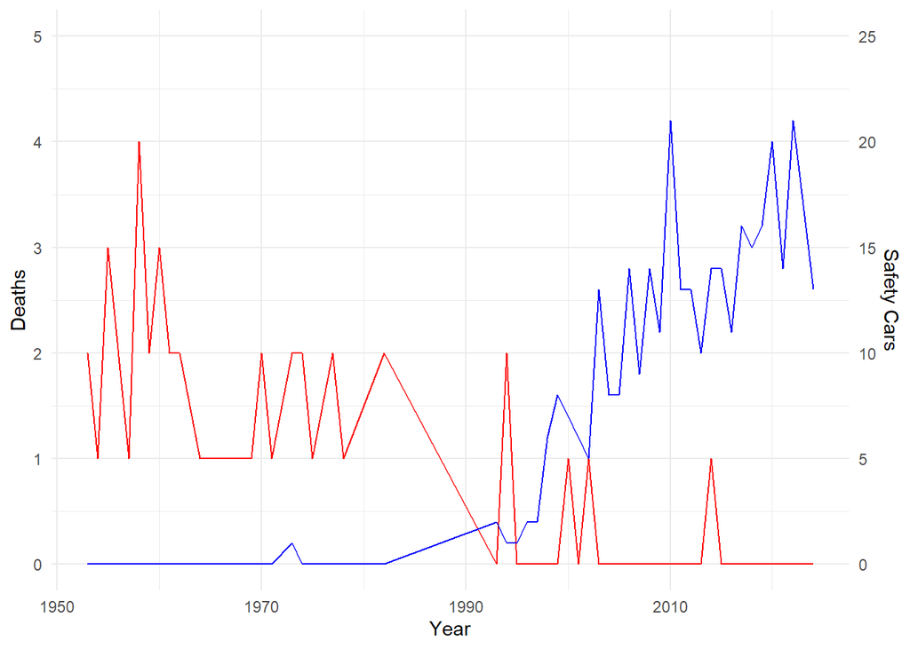

```r
DeathsByYear <- DriverDeaths %>% count(Year)

safetyCarByYear <- safetyCarData %>% count(Year)

StatsByYear <- full_join(DeathsByYear, safetyCarByYear, by = "Year") %>%
  dplyr::rename(Deaths = n.x, Safety_Cars = n.y)

LineChart <- StatsByYear %>%
  mutate(Deaths = ifelse(is.na(Deaths),0,Deaths)) %>%
  mutate(Safety_Cars = ifelse(is.na(Safety_Cars),0,Safety_Cars))

ggplot(LineChart, mapping = aes(x=Year)) + geom_line(aes(y=Deaths), color="red") + geom_line(aes(y=Safety_Cars / 5),color="blue") + scale_y_continuous(name = "Deaths", limits = c(0,5.), sec.axis = sec_axis(~.*5,name="Safety Cars")) + theme_minimal()
```

Very simply we see that as the FIA, the governing body in charge of formula one, has implemented more use of safety cars they have been able to make driver deaths a rarity rather than a common occurrence.

#### Deaths By Track

It is also useful to look at driver deaths based on the Location. For readablity we will look at only events where there are more than two driver deaths.

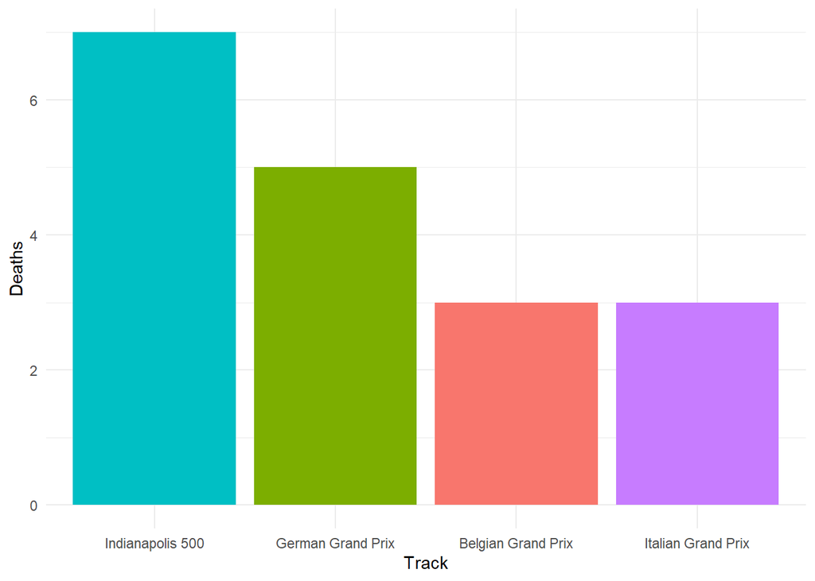

```r
DeathsByTrack <- DriverDeaths %>% count(Track) %>%
  filter(n > 1) %>%
  filter(nchar(Track) > 1)

TrackGraph <- DriverDeaths %>%
  filter(nchar(Track) > 1) %>%
  group_by(Track) %>%
  count() %>%
  filter(n > 2)

ggplot(TrackGraph,mapping = aes(x= reorder(Track,-n), y=n, fill = Track)) + geom_bar(stat = "identity") + labs(x = "Track", y = "Deaths") + theme_minimal() + theme(legend.position = "none")
```

It is clear that the Indianapolis 500 is a massive outlier, which makes sense given that the structure of the event was quite different than a typical race. However, this event has not been on the F1 calendar since 1960, which means leaving the race seems to be another factor in the increased safety of formula one in recent years.

## Conclusion

Formula one has implemented many safety features over the years that have improved the safety of the sport. Two major inclusions are the exit from the indianapolis 500 and the increased use of measures like safety cars. Now we all can enjoy the motorsport while knowing that any fatal accidents are much more rare than they once were.